# Replication Material Meet the Critics: Analyzing the EU Commission’s Regulatory Scrutiny Board through quantitative text analysis doi: https://doi.org/10.1111/rego.12312

Roman Senninger & Jens Blom-Hansen

Contact: rsenninger@ps.au.dk

# Data

Please visit https://dataverse.harvard.edu/dataverse/R_Senninger to download the data used in this manual.

# Load Required Packages

```r
library("quanteda")
library("ROCR")
library("separationplot")
library("visreg")
```

# Classifying new sentences

The code below shows how the Naive Bayes classifier that is presented in the article can be used to classify new sentences from RSB opinions. The new sentences used below are taken from the following RSB opinions: SEC(2019)327, SEC(2019)340, and SEC(2019)100.

```r
new_sentences <- c("The report does not show that EU Ecodesign regulation of only welding equipment would deliver significant benefits that justify the need for the EU to act.",

"The report does not sufficiently analyse current exemptions, i.e. explain what they cover, why they remain relevant, alternative ways to close loopholes, and the associated impacts.",

"The option concerning a stronger intervention based on V2V mandate and governance structure does not allow to address fully the issues at stake.")
```

Next, we pre-process the new sentences in the same manner as the training data and create a document-feature matrix.

```r
new_sentences  <- dfm(new_sentences,  tolower = TRUE,  stem = TRUE, remove = stopwords("english"), remove_numbers = TRUE, remove_punct = TRUE, remove_symbols = TRUE)
```

The Naive Bayes classifier can only take features into consideration that occur both in the training set and the test set. We can make the features identical by selecting only features that occur in the training set.

```r
load("./dfm.RData")

new_sentences <- dfm_select(new_sentences, training_dfm)
```

To classify our new sentences, we load the naive bayes model from the replication materials and use it to predict class propabilities for the new sentences. 1 represents the class ‘major change request’. 0 represents the class ‘no major change request’.

```r
load("./nb.RData")

pred_new_sentences <- predict(nb, new_sentences, type = "probability")

pred_new_sentences
```

```
##                0         1
## text1 0.19068569 0.8093143
## text2 0.01935025 0.9806497
## text3 0.77180417 0.2281958
```

# Reproduction

The remainder of this manual shows how our results can be reproduced. We start with study 1.

## Study 1

Reproduce Figure1:

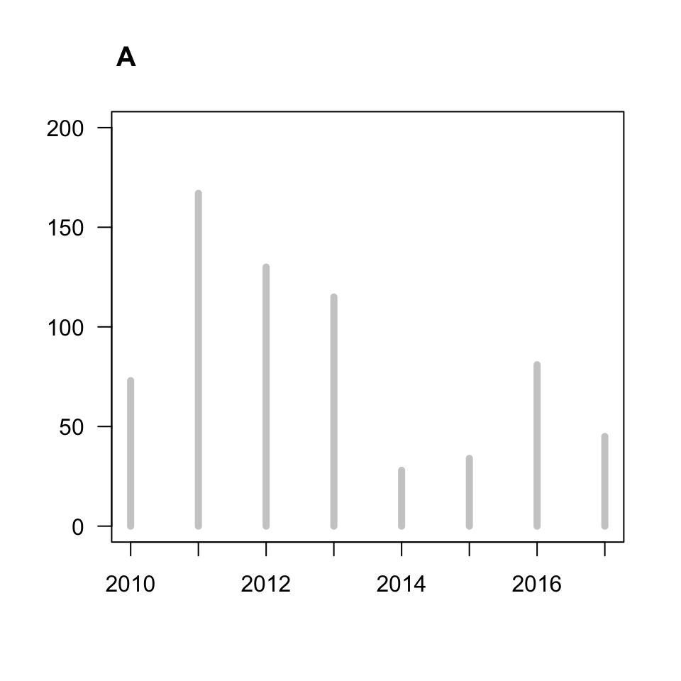

```r
load("./Fig1.RData")

#Panel A

plot(Fig1$year,Fig1$opinionsRSB, type = "h", col = "gray80", main="A", adj = 0.01, lwd = 5, ylim = c(0,200), xlab = "", ylab = "", yaxt = "n")
axis(side = 2, las = 2)
```

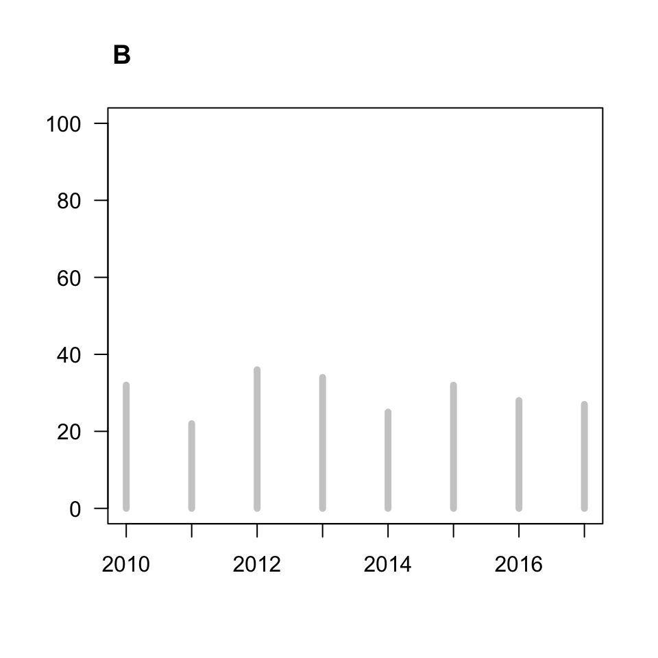

```r
#Panel B

plot(Fig1$year,Fig1$resubrate, type = "h", col = "gray80", main="B", adj = 0.01, lwd = 5, ylim = c(0,100), xlab = "", ylab = "", yaxt = "n")
axis(side = 2, las = 2)
```

Reproduce Figure 2:

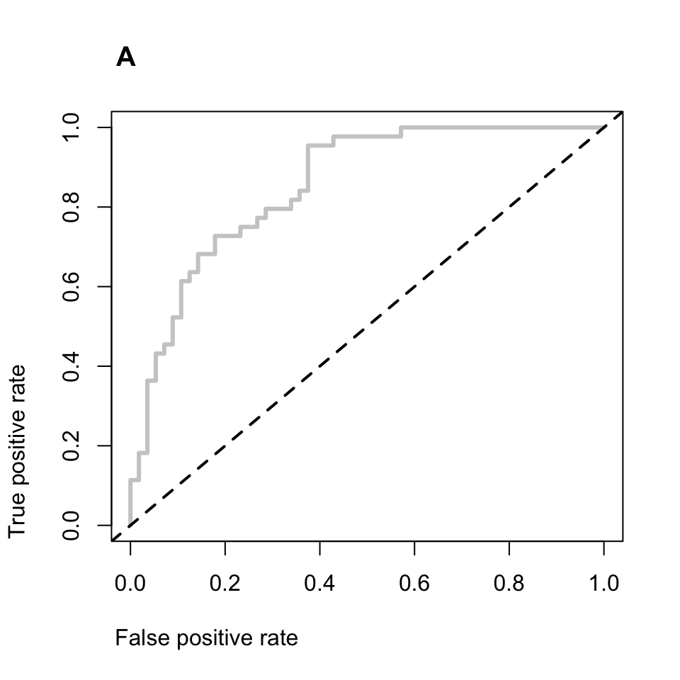

```r
load("./ROC.RData")

#Panel A

pred <- prediction(predictions = predicted_prob, labels = actual_class)
perf <- performance(pred, measure = "tpr", x.measure = "fpr")

plot(perf, main = "A", adj = 0.01, col = "gray80", lwd = 3, yaxt='n')
abline(a = 0, b = 1 , lwd = 2, lty = 2)
```

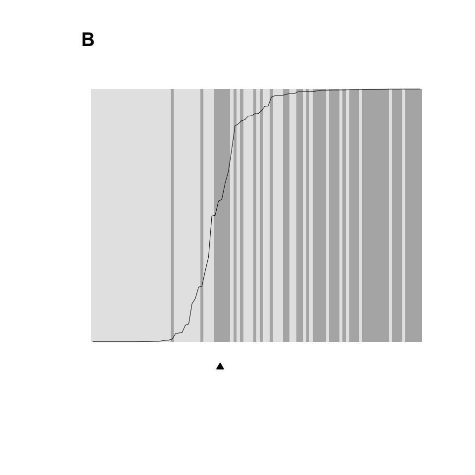

```r
#Panel B

load("./separation.RData")

separationplot(pred=predicted_class, actual=actual_class, type="rect", col0 = "gray90", col1 = "gray70", line=T, show.expected=T, newplot=F)
title("B", adj = 0.01)
```

Reproduce Figure 3:

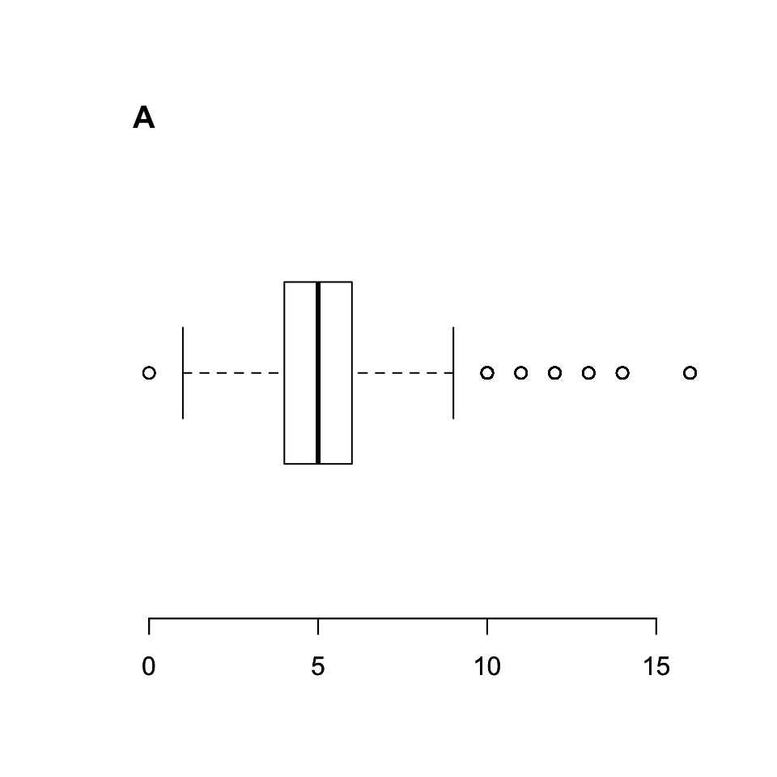

```r
load("./results_study1.RData")

#Panel A

par(bty="n")
boxplot(df_total$cr_n, horizontal = T, main = "")
axis(side = 1, las = 1)
title("A", adj = 0.01, line = 0)
```

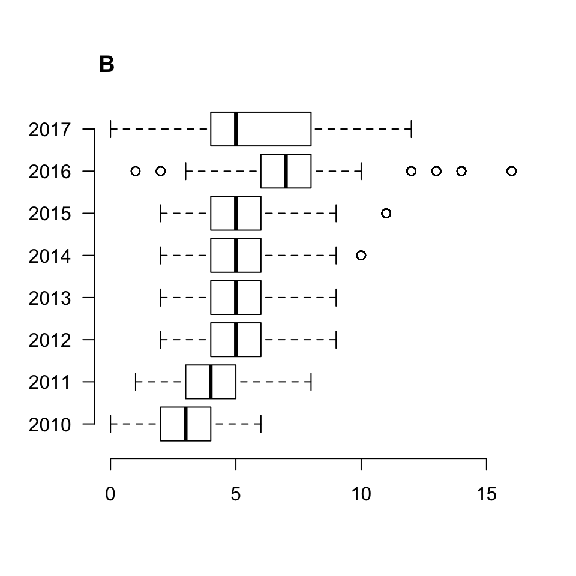

```r
#Panel B

par(bty="n")
boxplot(cr_n~year, data = df_subset, horizontal = T, main = "", las = 2, xaxt = 'n')
axis(side = 1, las = 1)
title("B", adj = 0.01, line = 1)
```

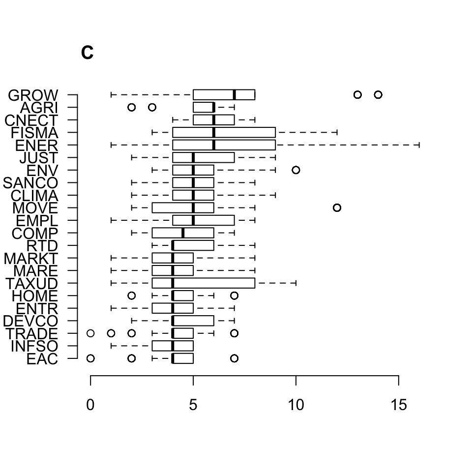

```r
#Panel C

par(bty="n")
DG2 <- with(df_subset, factor(DG, levels=levels(DG)[order(tapply(cr_n,DG,median))]))
boxplot(cr_n~DG2, data = df_subset, horizontal = T, main = "", las = 2, xaxt = 'n')
axis(side = 1, las = 1)
title("C", adj = 0.01, line = 1)
```

## Study 2

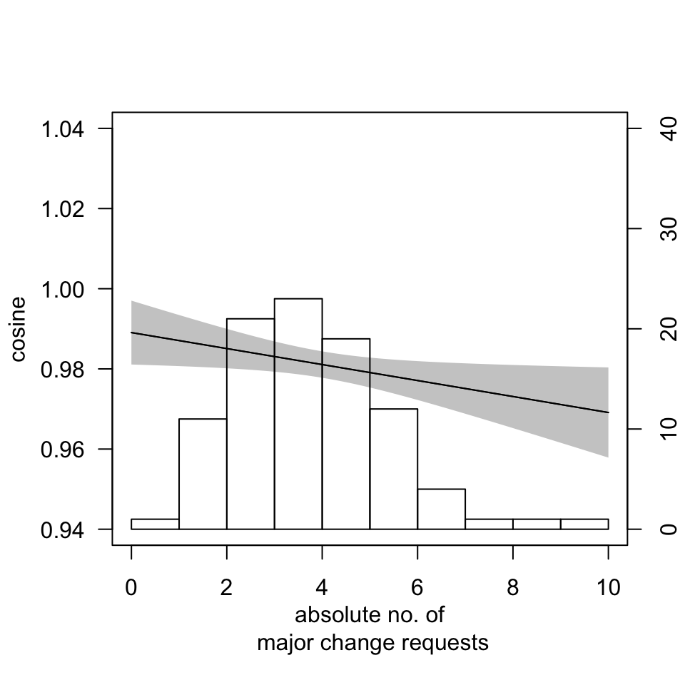

```r
load("./results_study2.RData")

visreg(model1, "cr_n",  scale = "response", type = "conditional", xlab="absolute no. of\n major change requests", ylab = "cosine", rug = F, main = "", alpha = 0.1,
       line=list(col="black", lwd=1),
       fill=list(col="gray80"), ylim=c(0.94, 1.04), xlim=c(0, 10))
  par(new= TRUE)
hist(RSB2data_1$cr_n, main = "", xlab = "", ylab = "", axes = F, ylim = c(0,40), xlim = c(0,10))
axis(4)
```

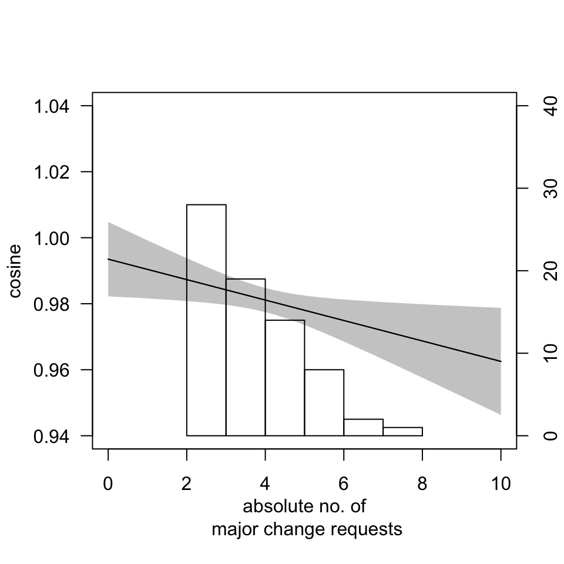

```r
visreg(model2, "cr_n",  scale = "response", xlab="absolute no. of\n major change requests", ylab = "cosine", rug = F, main = "", alpha = 0.1,
       line=list(col="black", lwd=1),
       fill=list(col="gray80"), ylim=c(0.94, 1.04), xlim=c(0, 10))
par(new= TRUE)
hist(RSB2data2011_1$cr_n, main = "", xlab = "", ylab = "", axes = F, ylim = c(0,40), xlim = c(0,10))
axis(4)
```

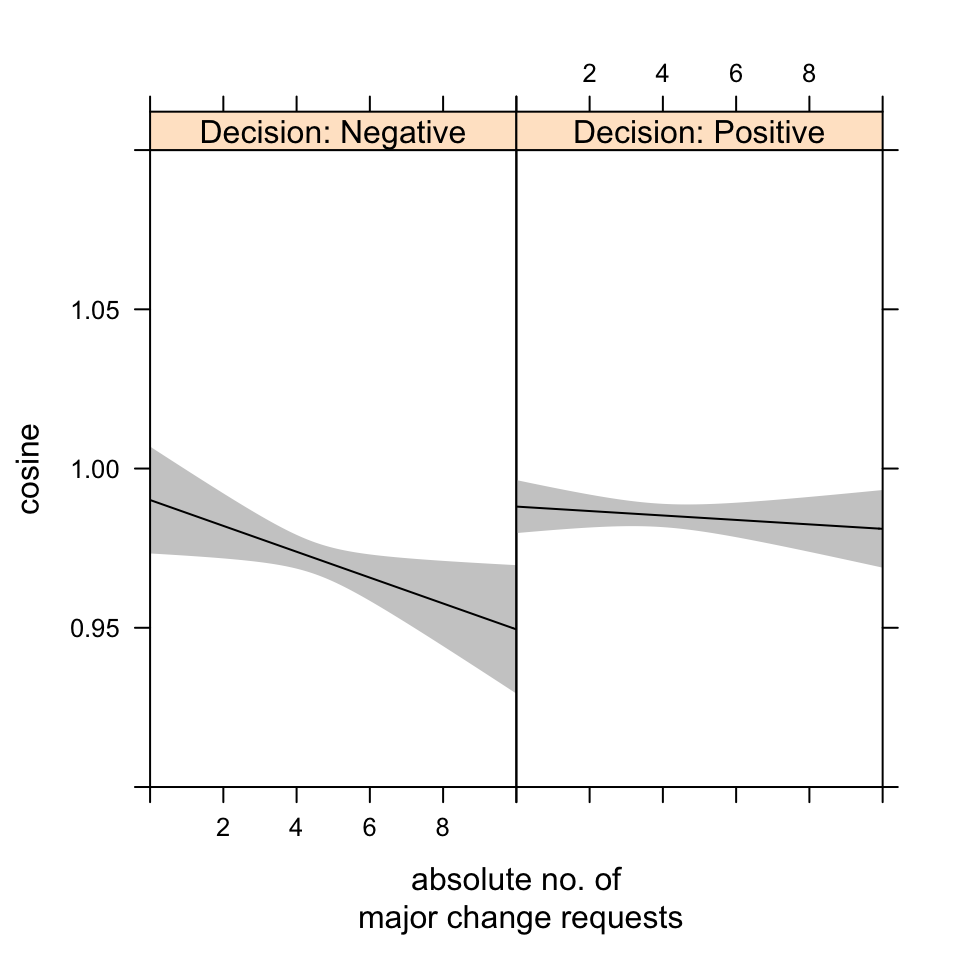

```r
visreg(model3, "cr_n",  by = "decision", scale = "response", xlab="absolute no. of\n major change requests", ylab = "cosine", rug = F, main = "", alpha = 0.1,
       line=list(col="black", lwd=1),
       fill=list(col="gray80"), ylim=c(0.9, 1.1), xlim=c(0, 10), strip.names=c("Decision: Negative", "Decision: Positive"))
```

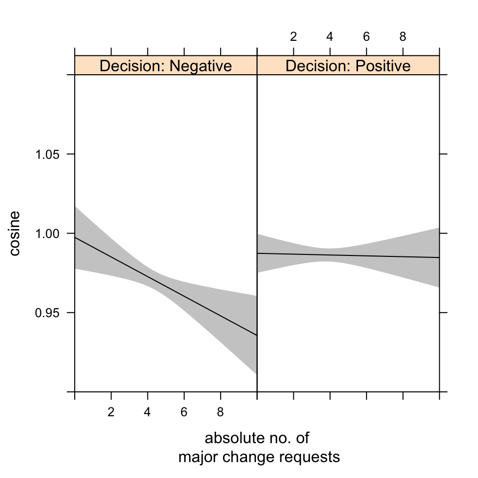

```r
visreg(model4, "cr_n",  by = "decision", scale = "response", xlab="absolute no. of\n major change requests", ylab = "cosine", rug = F, main = "", alpha = 0.1,
       line=list(col="black", lwd=1),
       fill=list(col="gray80"), ylim=c(0.9, 1.1), xlim=c(0, 10),strip.names=c("Decision: Negative", "Decision: Positive"))
```

# Additional Material

The replication material includes three document-feature matrices (training, testing, remaining) as described in the article. Moreover, the support vectore machine (svm) classifier is attached.

```r
load("./dfm.RData")
load("./svm.RData")
```